# Chapter 7: Unsupervised Machine Learning

## Key Ideas

Unsupervised machine learning, patterns, state, state transition, Markov Chain, clustering, association rule, confidence, support, lift, linear relationships, objective function, linear programming, simulation

# Finding Patterns

In **unsupervised machine learning**, Occam algorithms search for ways to organize observations into abstract **patterns**. These patterns satisfy specific rules (like every element has to fit neatly into a region) and often match concrete, real-world concepts (like fruits, vegetables, and proteins).

# Markov Chains

A **state** describes status. For example, when pursuing new business, customers can be described as being in the *new, existing, lost* or *premium* state.

```r
#function to check if a package is installed
is_installed <- function(mypkg) is.element(mypkg, installed.packages()[,1])
#build a network of states and the probability of state transition
if(!is_installed("markovchain")){install.packages("markovchain")}
library(markovchain)
#markov chain states
customer.states <- c("existing","lost","new", "premium")
```

State-transition observations record the history of state changes. For example, we can record the state transition of all customers over a two-year period.

```r
#create data simulating the 2 year history of a customer's status
yr1 <- c("new", "new", "new", "premium", "premium", "premium", "lost", "lost", "existing", "existing", "existing", "existing", "existing", "new")
yr2 <- c("existing", "lost", "lost", "premium", "premium", "lost", "lost", "lost", "premium", "existing", "lost", "existing", "existing", "new")
cid <- 1:14
customer.history <- cbind.data.frame(cid, yr1, yr2)
customer.history
```

```
   cid      yr1      yr2
1    1      new existing
2    2      new     lost
3    3      new     lost
4    4  premium  premium
5    5  premium  premium
6    6  premium     lost
7    7     lost     lost
8    8     lost     lost
9    9 existing  premium
10  10 existing existing
11  11 existing     lost
12  12 existing existing
13  13 existing existing
14  14      new      new
```

The **Markov Chain** algorithm is an O(N^2) search that organizes state-transition observations into a network. Each node of the network must be a unique state from the state-transition observations. Each link in the network must be the probability (calculated from observation) of transitioning from one state to the next.

For example, we can take the state-transition observations of our customers and convert it into a Markov Chain. We find that *premium* customers often stay that way (0.67) but there is a a chance (.33) that we lose them.

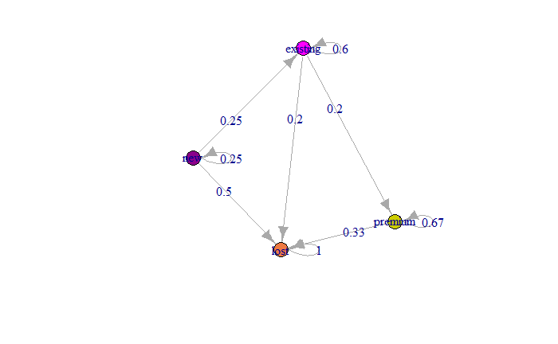

```r
#convert the customer history to an occurance table
customer.occurance <- table(customer.history$yr1, customer.history$yr2)
#convert the occurance table to a transition matrix
customer.transition <- customer.occurance /rowSums(customer.occurance)
customer.transition <- as.matrix.data.frame(customer.transition)
#create a markov chain
customer.markov <- new("markovchain", transitionMatrix = customer.transition,  states = customer.states, name ="customer markov chain")
plot(customer.markov)
```

```r
#predict the most likely state of a new customer after 4 years
customer.initialState<-c(0,0,1,0)
steps<-4
customer.finalState<-customer.initialState*customer.markov^steps #using power operator
customer.finalState
```

```
       existing      lost        new    premium
[1,] 0.08978125 0.8271319 0.00390625 0.07918056
```

```r
#predict the long-term tendency of customers
steadyStates(customer.markov)
```

```
     existing lost new premium
[1,]        0    1   0       0
```

# Clustering

**Clustering** algoritms are O(NlogN) searches that organize observations into spaces and clusters within the space. For example, we can apply a clustering algorithm to Iris observations.

```r
#use the iris data
iris.test <- iris
#create a training set with the species column to null,
#we'll try to guess the species from clustering
iris.train <- iris.test
iris.train$Species <- NULL
#create 3 clusters from k-means
kmeans.result <- kmeans(iris.train, 3)
kmeans.result
```

```
K-means clustering with 3 clusters of sizes 21, 96, 33

Cluster means:
  Sepal.Length Sepal.Width Petal.Length Petal.Width
1     4.738095    2.904762     1.790476   0.3523810
2     6.314583    2.895833     4.973958   1.7031250
3     5.175758    3.624242     1.472727   0.2727273

Clustering vector:
  [1] 3 1 1 1 3 3 3 3 1 1 3 3 1 1 3 3 3 3 3 3 3 3 3 3 1 1 3 3 3 1 1 3 3 3 1 3 3 3 1 3 3 1
 [43] 1 3 3 1 3 1 3 3 2 2 2 2 2 2 2 1 2 2 1 2 2 2 2 2 2 2 2 2 2 2 2 2 2 2 2 2 2 2 2 2 2 2
 [85] 2 2 2 2 2 2 2 2 2 1 2 2 2 2 1 2 2 2 2 2 2 2 2 2 2 2 2 2 2 2 2 2 2 2 2 2 2 2 2 2 2 2
[127] 2 2 2 2 2 2 2 2 2 2 2 2 2 2 2 2 2 2 2 2 2 2 2 2

Within cluster sum of squares by cluster:
[1]  17.669524 118.651875   6.432121
 (between_SS / total_SS =  79.0 %)

Available components:

[1] "cluster"      "centers"      "totss"        "withinss"     "tot.withinss"
[6] "betweenss"    "size"         "iter"         "ifault"
```

Each cluster must be well defined and loosely coupled.

```r
#we want well-defined clusters (total sum of squares)
vagueness <- kmeans.result$totss
#we want loosely coupled clusters (between sum of squares)
loose_coupling <- kmeans.result$betweenss
#estimate the effectiveness of the clustering
variance_explained <- loose_coupling / vagueness
print(paste("The estimated effectiveness of the clustering", variance_explained))
```

```
[1] "The estimated effectiveness of the clustering 0.790490637515553"
```

When clustering species of Iris, for example, the resulting clusters may correspond to Iris species.

```r
#show how the clusters align with the species
table(iris.test$Species, kmeans.result$cluster)
```

```
              1  2  3
  setosa     17  0 33
  versicolor  4 46  0
  virginica   0 50  0
```

# Association Rules

The **Association Rule** algorithm is an O(N^2) search for general if-then rules that fit specific observations. For example, for observations of Titanic passengers…

```r
#grab the titanic data
df <- as.data.frame(Titanic)
#process the data for rule mining
titanic.raw <- NULL
for (i in 1:4) {titanic.raw <- cbind(titanic.raw, rep(as.character(df[,i]), df$Freq))}
titanic.raw <- as.data.frame(titanic.raw)
names(titanic.raw) <- names(df)[1:4]
titanic.raw[1:10,]
```

```
   Class  Sex   Age Survived
1    3rd Male Child       No
2    3rd Male Child       No
3    3rd Male Child       No
4    3rd Male Child       No
5    3rd Male Child       No
6    3rd Male Child       No
7    3rd Male Child       No
8    3rd Male Child       No
9    3rd Male Child       No
10   3rd Male Child       No
```

…we can discover association rules describing the observations.

```r
# find association rules with default settings
if(!is_installed("arules")){install.packages("arules")}
library(arules)
rules.all <- apriori(titanic.raw)
```

```
Apriori

Parameter specification:
 confidence minval smax arem  aval originalSupport maxtime support minlen maxlen target
        0.8    0.1    1 none FALSE            TRUE       5     0.1      1     10  rules
   ext
 FALSE

Algorithmic control:
 filter tree heap memopt load sort verbose
    0.1 TRUE TRUE  FALSE TRUE    2    TRUE

Absolute minimum support count: 220

set item appearances ...[0 item(s)] done [0.01s].
set transactions ...[10 item(s), 2201 transaction(s)] done [0.02s].
sorting and recoding items ... [9 item(s)] done [0.01s].
creating transaction tree ... done [0.00s].
checking subsets of size 1 2 3 4 done [0.02s].
writing ... [27 rule(s)] done [0.01s].
creating S4 object  ... done [0.01s].
```

Each if-then rule should be corrrect (confidence), apply to actual observations (support), and work better than random guessing (lift).

```r
#inspect the rules
inspect(rules.all[1:10,])
```

```
     lhs               rhs         support   confidence lift      count
[1]  {}             => {Age=Adult} 0.9504771 0.9504771  1.0000000 2092
[2]  {Class=2nd}    => {Age=Adult} 0.1185825 0.9157895  0.9635051  261
[3]  {Class=1st}    => {Age=Adult} 0.1449341 0.9815385  1.0326798  319
[4]  {Sex=Female}   => {Age=Adult} 0.1930940 0.9042553  0.9513700  425
[5]  {Class=3rd}    => {Age=Adult} 0.2848705 0.8881020  0.9343750  627
[6]  {Survived=Yes} => {Age=Adult} 0.2971377 0.9198312  0.9677574  654
[7]  {Class=Crew}   => {Sex=Male}  0.3916402 0.9740113  1.2384742  862
[8]  {Class=Crew}   => {Age=Adult} 0.4020900 1.0000000  1.0521033  885
[9]  {Survived=No}  => {Sex=Male}  0.6197183 0.9154362  1.1639949 1364
[10] {Survived=No}  => {Age=Adult} 0.6533394 0.9651007  1.0153856 1438
```

```r
#lhs: left hand side (if part of the if-then statement)
#rhs: right hand side (then part of the if-then statement)
#support: how frequently the combinations occur
#confidence: percent of time the rule is true
#lift: the rule's performance compared to random guessing
#count: the number of observations the rule describes
```

# Linear Programming

**Linear relationships** can be described using simple multiplication. For example,

Labor:

- It costs 4 hours per women’s shoe made
- It costs 3 hours per men’s shoe made
- We can only work 40 hours per week

Material:

- It takes 0.2 sq. meters of leather per women’s shoe
- It takes 0.3 sq. meters of leather per men’s shoe
- We can only use 3 sq meters of leather per week

Profit:

- You make $36 profit per women’s shoe sold
- You make $34 profit per men’s shoe sold

We can summarize this system of relationships as follows

| Relationship | W | M | Constraint |
| --- | --- | --- | --- |
| Labor | 4 | 3 | <= 40 |
| Material | 0.2 | 0.3 | <= 3 |
| Profit | $36 | $34 | as much as possible |

We can capture the labor and material relationships using a matrix.

```r
#linear programming
if(!is_installed("lpSolve")){install.packages("lpSolve")}
library(lpSolve)
f.con <- matrix (c(4,3,0.2,0.3), nrow=2, byrow=TRUE)
f.dir <- c("<=", "<=")
f.rhs <- c(40,3)
```

Because the objective is to maximize profit we can capture the profit relationship as an **objective function**– a relationship that we intend to optimize.

```r
f.obj <- c(36, 34)
```

The **Linear Programming** algorithm is an O(N^2) search for observations that fit a pattern of linear relationships and that optimize the objective function. For example, given the linear relationships above, how many pairs of mens and womens shoes should we make to maximize profit?

```r
solution <- lp ("max", f.obj, f.con, f.dir, f.rhs)$solution
print(paste("We should make", solution[1], "women's shoes and", solution[2], "men's shoes"))
```

```
[1] "We should make 5 women's shoes and 6.66666666666667 men's shoes"
```

# Simulation

Simulation is the creation of a new sample that has the same qualities (feature correlation, feature distribution, feature scale) of an existing sample.

For example, we can use the qualities of an existing sample of Iris flowers to create a new sample with those same qualities. We start by generating a new sample whose features correlate the same as the existing sample. Each individual observation is generated randomly but, overall, the features are correlated to match the original sample.

```r
require(mvtnorm)
#use the iris data
iris.data <- iris[,1:4]
iris.cmatrix <- cor(iris.data)
#start the simulation as a set of random, guaussian variable
#correlated according to the matrix
simulation_runs = 10000
number_of_features = 4
feature_means <- rep(0,number_of_features)
iris.sim <- rmvnorm(mean=feature_means,sig=iris.cmatrix,n=simulation_runs)
#rename the simulation variables to match the observations
colnames(iris.sim) <- colnames(iris.data)
iris.sim[1:10,]
```

```
      Sepal.Length Sepal.Width Petal.Length Petal.Width
 [1,]  -0.33578029 -1.00620445   -0.2709171  -0.2977600
 [2,]  -1.93166404  0.47935725   -1.6270725  -2.0758261
 [3,]  -0.25486106 -0.10913217    0.7293421   0.9564436
 [4,]  -0.03004956  1.72644056   -1.1970847  -1.1113274
 [5,]  -0.70420601 -0.75769100   -0.8626586  -0.6309623
 [6,]   0.52873123  1.26882927   -0.1807757  -0.8164530
 [7,]   2.09551909  0.12555369    1.0231936   0.5934707
 [8,]  -0.84729361  0.88844427   -0.7219568  -0.5019031
 [9,]  -0.64830684  0.07915868   -0.9398560  -0.7358937
[10,]  -0.50533871 -0.52493620   -0.3042224  -0.2579223
```

Next, we want the distribution of each simulated feature to match the real, observed features. In the uniform distibution a feature’s values are evenly distributed among all possibilities. Because a feature in the uniform distribution can be molded into any other distribution, we put all simulated features into the uniform distribution.

```r
#convert the simulation variables to a uniform distribution
iris.sim <- pnorm(iris.sim)
iris.sim <- as.data.frame(iris.sim)
```

Now we can mold the distribution of each simulated feature to match the distribution of the corresponding observed feature.

```r
#convert the simulated variables to distributions
#that match observation
#fit sepal length to a beta distribution
library(fitdistrplus)
library(scales)
parm <- fitdist(rescale(iris.data$Sepal.Length,c(0.01,.99)),"beta")
iris.sim$Sepal.Length <- qbeta(iris.sim$Sepal.Length,
                               shape1 = parm$estimate[1],
                               shape2 = parm$estimate[2])
#fit sepal width to a lognormal distribution
parm <- fitdist(iris.data$Sepal.Width,"lnorm")
iris.sim$Sepal.Width <- qlnorm(iris.sim$Sepal.Width,meanlog = parm$estimate[1], sdlog = parm$estimate[2])
#fit petal length to a beta distribution
parm <- fitdist(rescale(iris.data$Petal.Length,c(0.01,.99)),"beta")
iris.sim$Petal.Length <- qbeta(iris.sim$Petal.Length,
                               shape1 = parm$estimate[1],
                               shape2 = parm$estimate[2])
#leave petal width as a uniform disribution
```

We can change the scale of each simulated feature to match the scale of the corresponding observed feature.

```r
#place simulated variables into the proper scale
iris.sim$Sepal.Length <- rescale(iris.sim$Sepal.Length,
                                 c(min(iris.data$Sepal.Length),
                                   max(iris.data$Sepal.Length)))
iris.sim$Sepal.Width <- rescale(iris.sim$Sepal.Width,
                                 c(min(iris$Sepal.Width),
                                   max(iris$Sepal.Width)))
iris.sim$Petal.Length <- rescale(iris.sim$Petal.Length,
                                c(min(iris$Petal.Length),
                                  max(iris$Petal.Length)))
iris.sim$Petal.Width <- rescale(iris.sim$Petal.Width,
                                 c(min(iris$Petal.Width),
                                   max(iris$Petal.Width)))
```

Although each simulated Iris observation was generated using random feature values, the statistical properties of the simulated population match the statistical properties of the real population. Although the simulation is not real, it is realistic.

```r
summary(iris.sim$Sepal.Length)
```

```
   Min. 1st Qu.  Median    Mean 3rd Qu.    Max.
  4.300   5.202   5.834   5.878   6.502   7.900
```

```r
summary(iris.data$Sepal.Length)
```

```
   Min. 1st Qu.  Median    Mean 3rd Qu.    Max.
  4.300   5.100   5.800   5.843   6.400   7.900
```

We can judge the value of a simulation based on how well its statistical properties correspond to a real population.

```r
library(ggplot2)
#create plots to compare the disributions of the observed and simulated data
p1.sim <- qplot(iris.sim$Sepal.Length, geom="histogram",
                binwidth=.25, col="red", main = "Simulated Sepal Length",
                xlab = "Sepal Length")
p1.obs <- qplot(iris.data$Sepal.Length, geom="histogram",
                binwidth=.25, col="red", main = "Observed Sepal Length",
                xlab = "Sepal Length")
p2.sim <- qplot(iris.sim$Sepal.Width, geom="histogram",
                binwidth=.25, col="red", main = "Simulated Sepal Width",
                xlab = "Sepal Width")
p2.obs <- qplot(iris.data$Sepal.Width, geom="histogram",
                binwidth=.25, col="red", main = "Observed Sepal Width",
                xlab = "Sepal Width")
p3.sim <- qplot(iris.sim$Petal.Length, geom="histogram",
                binwidth=.25, col="red", main = "Simulated Petal Length",
                xlab = "Petal Length")
p3.obs <- qplot(iris.data$Petal.Length, geom="histogram",
                binwidth=.25, col="red", main = "Observed Petal Length",
                xlab = "Petal Length")
p4.sim <- qplot(iris.sim$Petal.Width, geom="histogram",
                binwidth=.25, col="red", main = "Simulated Petal Width",
                xlab = "Petal Length")
p4.obs <- qplot(iris.data$Petal.Width, geom="histogram",
                binwidth=.25, col="red", main = "Observed Sepal Width",
                xlab = "Sepal Length")
#show the plot comparing the distributions
library(gridExtra)
grid.arrange(p1.obs, p2.obs, p3.obs, p4.obs,
             p1.sim, p2.sim, p3.sim, p4.sim,
             ncol=4, nrow=2)
```

[output not shown]

Simulation helps discover new possibilities. For example, comparing the observed Iris sample to the simulations show possibilities for a new, not yet observed, species of Iris.

```r
##  Set up plotting in two rows and three columns, plotting along rows first.
#get( getOption( "device" ) )()
par( mfrow = c( 1, 2 ) )
#create and plot clusters that represent the observied iris species
kmeans.result <- kmeans(iris.data, 4)
plot(iris.data[c("Petal.Length", "Petal.Width")], col = kmeans.result$cluster, main="Observed Iris Sample")
points(kmeans.result$centers[,c("Petal.Length", "Petal.Width")],
       col = 1:3, pch = 8, cex=2)
```

[figure not shown]

```r
#create and plot clusters that represent the simulated iris species
kmeans.result <- kmeans(iris.sim, 5)
plot(iris.sim[c("Petal.Length", "Petal.Width")], col = kmeans.result$cluster, main="Simulated Iris Sample")
```

[output not shown]